# Session 1 — Missing Data: Patterns and Mechanisms

MCAR · MAR · MNAR · patterns · comparing complete and incomplete · testing · Lab 1

Community Medicine Workshop

## Where we are

- All earlier workshops quietly **dropped rows with missing values**
- Today: **why that can mislead**, and how to **describe** missing data
- By the end you can:
  - describe the **amount and pattern** of missingness
  - name the three **mechanisms** (MCAR, MAR, MNAR)
  - **explore** whether missingness depends on observed data
  - say what the data **cannot** tell you

## Our data: an NCD cohort with gaps

- **2,000 adults** (synthetic): age, sex, education, BMI, smoking, activity, SBP, HbA1c
- Missing: **BMI 26%**, **HbA1c 21%**, **activity 12%**, **smoking 9%**, **SBP 6%**
- Age, sex and education are complete
- Only **45%** of adults have **every** variable

```r
ncd |> head(8)
```

```
# A tibble: 8 × 9
  id      age sex    education    bmi smoker activity   sbp hba1c
  <chr> <dbl> <fct>  <fct>      <dbl>  <dbl>    <dbl> <dbl> <dbl>
1 C0001    50 Female Secondary+  26.4      0      3.2   117   5.2
2 C0002    63 Male   Secondary+  NA        1      0.8   164  NA
3 C0003    64 Female Primary     23.7      0      3.8   118  NA
4 C0004    62 Female Secondary+  NA        0      4.7   128   5.8
5 C0005    73 Male   Secondary+  22.2      1      4.3   130   5.2
6 C0006    26 Male   None        21.7      0      7.7   118   5.4
7 C0007    62 Female None        34.8      0      1.4   143  NA
8 C0008    45 Female Secondary+  26.3      0      7.8   132   5.1
```

# Topic 1 — Mechanisms

## Three mechanisms

| Mechanism | Missingness depends on… | Example here |
| --- | --- | --- |
| **MCAR** (completely at random) | nothing | a form lost at random (smoking, 9%) |
| **MAR** (at random) | **observed** data | BMI missing more in **older men with a high SBP** |
| **MNAR** (not at random) | the **missing value itself** | high **HbA1c** more often missing |

The names are confusing: in **MAR** the missingness is **not random** at all; it is **explained by other observed variables**. That is what allows us to **correct** for it.

## Why it matters

- **MCAR**: complete-case analysis is **unbiased** but loses **precision**
- **MAR**: complete-case can be **biased**; **multiple imputation** (and likelihood methods) are **valid**
- **MNAR**: **no method** is valid without an **assumption** about the missing values: do a **sensitivity analysis**
- You **cannot tell MAR from MNAR** from the observed data alone

# Topic 2 — Describing missing data

## How much and which pattern?

```r
round(100 * colMeans(is.na(ncd)), 1)
```

```
       id       age       sex education       bmi    smoker  activity       sbp
      0.0       0.0       0.0       0.0      26.4       9.2      12.2       5.9
    hba1c
     20.5
```

```r
sum(complete.cases(ncd))
```

```
[1] 905
```

```r
md.pattern(dat, plot = FALSE) |> head(3)
```

```
    age sex education sbp smoker activity hba1c bmi
905   1   1         1   1      1        1     1   1 0
296   1   1         1   1      1        1     1   0 1
196   1   1         1   1      1        1     0   1 1
```

**905** adults (45%) are complete; then **BMI alone missing (296)** and **HbA1c alone (196)**: **26 patterns** in all.

## A picture

```r
gg_miss_upset(dat, nsets = 5)
```

An **UpSet plot** shows the commonest **combinations** of missing variables. Also useful: `vis_miss(dat)` and `miss_var_summary(dat)`.

## A picture

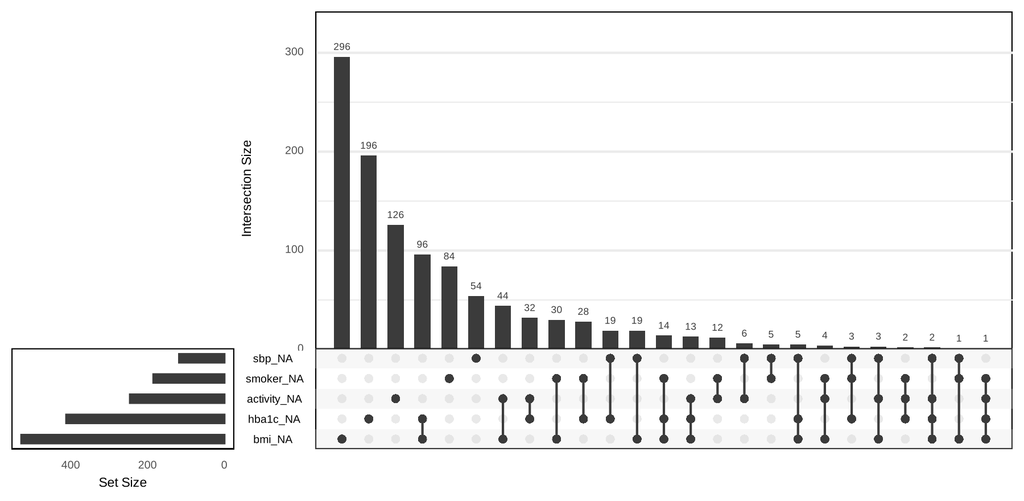

# Topic 3 — What drives the missingness?

## Compare with and without BMI

```r
dat |> group_by(bmi_missing = is.na(bmi)) |> summarise(n = n(), age = round(mean(age), 1), sbp = round(mean(sbp, na.rm = TRUE)), men = round(mean(sex == "Male"), 2))
```

```
# A tibble: 2 × 5
  bmi_missing     n   age   sbp   men
  <lgl>       <int> <dbl> <dbl> <dbl>
1 FALSE        1472  45.3   121  0.44
2 TRUE          528  53.9   135  0.63
```

Adults with a missing BMI are **older (54 vs 45)**, **more often men (63% vs 44%)** and have a **higher SBP (135 vs 121)**. The data are **not MCAR**. Because the differences are in **observed** variables, **MAR** is plausible.

## Model the missingness

```r
m_miss <- glm(is.na(bmi) ~ age + sex + education + sbp, data = dat, family = binomial)
round(summary(m_miss)$coefficients, 3)
```

```
                    Estimate Std. Error z value Pr(>|z|)
(Intercept)          -16.339      0.855 -19.107    0.000
age                    0.025      0.005   4.637    0.000
sexMale                0.729      0.126   5.765    0.000
educationPrimary       0.165      0.157   1.053    0.292
educationSecondary+    0.082      0.155   0.530    0.596
sbp                    0.106      0.007  16.131    0.000
```

- Age, male sex and **especially SBP** (z = 16) predict a missing BMI; education does not
- This is evidence for **MAR**: and a warning that **SBP, the outcome, must be in the imputation model**

## Little’s MCAR test

```r
dat |> mutate(male = as.integer(sex == "Male")) |> select(age, male, bmi, smoker, activity, sbp, hba1c) |> mcar_test()
```

```
# A tibble: 1 × 4
  statistic    df p.value missing.patterns
      <dbl> <dbl>   <dbl>            <int>
1      772.   118       0               26
```

p < 0.001: **MCAR is rejected**. That does **not** prove **MAR**: **MNAR cannot be tested** from the data, because the values that decide it are the ones **you do not have**. Argue it from **subject knowledge** (why would a value be missing?), then do a **sensitivity analysis** (Session 5).

## 🔧 Switch to R — Lab 1

**File:** `missing-workshop/labs/lab1_pattern.R`

- percent missing, complete cases, patterns
- UpSet plot and a table of missingness
- who is missing: comparison, logistic model, Little’s test

**Time:** 35 minutes · answer the Q questions in the comments

## Self-check quiz (1/5)

Older men are more often missing BMI, and they also have a higher observed SBP. Which mechanism is the most plausible?

- Missing at random: missingness depends on observed variables
- Missing completely at random: missingness is unrelated to the data
- Missing not at random: missingness depends on the unobserved BMI itself
- No mechanism applies, since a part of the BMI values is observed

## Self-check quiz (2/5)

Little’s test rejects MCAR (p < 0.001). What can you conclude?

- The data are MNAR, so multiple imputation cannot be used on them
- The data are not MCAR, but this does not tell MAR from MNAR
- The data are MAR, since MCAR is the other simple mechanism left
- Nothing can be concluded, because the test applies to categorical variables

## Self-check quiz (3/5)

Why can MNAR not be tested using the observed data?

- The sample is too small for a test to be able to detect the effect
- Tests exist for it, but they need survey weights in order to work
- MNAR occurs when a large share of the values (above half) is missing
- The values that determine the missingness are not observed

## Self-check quiz (4/5)

Only 45% of adults are complete. What is the main problem with complete-case analysis here?

- It loses precision, and may be biased if complete cases are selected
- It makes the standard errors too small, because fewer adults are analysed in the model
- It turns the variables into categories, which loses information on each variable
- It cannot be run in R unless the missing values are first recoded as zero

## Self-check quiz (5/5)

A pattern table shows 905 complete rows and 296 rows with only BMI missing. What does it help you decide?

- Whether the missing values in this dataset are random or not random in nature
- Which adults should be deleted from the dataset before the analysis starts
- Which variables are missing together, and where imputation matters most
- How many imputations are needed to get unbiased estimates from the data

## Score and take-home

**Your score:**

- **MCAR / MAR / MNAR**: what the missingness depends on
- **Describe**: % missing, complete cases, patterns, plots
- **Compare** observed variables between complete and incomplete; model the missingness
- **MNAR cannot be tested**: argue it, then do a sensitivity analysis
- Include the **outcome** among the variables that explain missingness

**Next:** Session 2: simple methods and why they fail